# Movie recommendation system

Maria Novosolov

04 August 2022

Recommendation systems today can be found everywhere, from the movies we watch in platforms such as Netflix and HBO, to music such as Spotify, and e-commerce. In the field of recommendation systems there are several challenges such as how to create recommendations to new users, how to recommend new content to users that don’t rate the content they consume, or how to recommend new content to users with diverse tastes. The research into these questions and several others is on going and new ways of improving recommendation systems are constantly emerging.

In this project I will use the MovieLens 100K dataset from keggle to build a recommendation system. I will compare several commonly used models with various performance criteria. Specifically I will focus on 4 different models:

1. Popularity based recommendation
2. User-based Collaborative filtering
3. Item-based Collaborative filtering
4. Matrix Factorization

# Loading the data

I am loading three datasets that come as part of the MovieLens dataset and the zip code coordinates data downloaded from the internet

#### User-Movie data

A long format table with users, the movies that they ranked, the ranking they gave it, and a timestemp representing the time when the movie was ranked

```r
movie_user<- read_delim(here::here("ml-100k/u.data"),col_names = F) %>%
  rename(user.id = X1, movie.id = X2, rank = X3, timeUnix = X4) %>%
  mutate(timeUnix = as_datetime(timeUnix)) %>%
  mutate(user.id = as.character(user.id),movie.id = as.character(movie.id)) %>%
  group_by(user.id) %>%
  mutate(rank_norm = norm_rank(rank)) %>%
  ungroup()
summary(movie_user)
```

```
##    user.id            movie.id              rank
##  Length:100000      Length:100000      Min.   :1.00
##  Class :character   Class :character   1st Qu.:3.00
##  Mode  :character   Mode  :character   Median :4.00
##                                        Mean   :3.53
##                                        3rd Qu.:4.00
##                                        Max.   :5.00
##     timeUnix                         rank_norm
##  Min.   :1997-09-20 03:05:10.000   Min.   :-3.7241
##  1st Qu.:1997-11-13 19:18:29.500   1st Qu.:-0.6575
##  Median :1997-12-22 21:42:24.000   Median : 0.1016
##  Mean   :1997-12-31 00:40:51.488   Mean   : 0.0000
##  3rd Qu.:1998-02-23 18:53:04.000   3rd Qu.: 0.7327
##  Max.   :1998-04-22 23:10:38.000   Max.   : 3.5080
```

#### Movie data

A detailed dataset with variable features that describe each movie, such as title, release date, and matrix of garners it belongs to

```r
movie_data<- read_delim(here::here("ml-100k/u.item"),col_names = F) %>%
  rename(movie.id  = X1, movie_title = X2, release_date = X3, video_release_date = X4,
           IMDb_URL = X5, unknown = X6, Action = X7, Adventure = X8, Animation = X9,
           Children = X10, Comedy = X11, Crime = X12, Documentary = X13, Drama = X14, Fantasy = X15, Film_Noir = X16, Horror = X17, Musical = X18, Mystery = X19, Romance = X20, Sci_Fi = X21,
Thriller = X22, War = X23, Western = X24) %>%
  mutate(movie.id = as.character(movie.id))
movie_data_sub<- movie_data %>%
  select(movie.id,movie_title)

summary(as_tibble(movie_data))
```

```
##    movie.id         movie_title        release_date       video_release_date
##  Length:1682        Length:1682        Length:1682        Mode:logical
##  Class :character   Class :character   Class :character   NA's:1682
##  Mode  :character   Mode  :character   Mode  :character
##
##
##
##    IMDb_URL            unknown             Action         Adventure
##  Length:1682        Min.   :0.000000   Min.   :0.0000   Min.   :0.00000
##  Class :character   1st Qu.:0.000000   1st Qu.:0.0000   1st Qu.:0.00000
##  Mode  :character   Median :0.000000   Median :0.0000   Median :0.00000
##                     Mean   :0.001189   Mean   :0.1492   Mean   :0.08026
##                     3rd Qu.:0.000000   3rd Qu.:0.0000   3rd Qu.:0.00000
##                     Max.   :1.000000   Max.   :1.0000   Max.   :1.00000
##    Animation          Children           Comedy           Crime
##  Min.   :0.00000   Min.   :0.00000   Min.   :0.0000   Min.   :0.0000
##  1st Qu.:0.00000   1st Qu.:0.00000   1st Qu.:0.0000   1st Qu.:0.0000
##  Median :0.00000   Median :0.00000   Median :0.0000   Median :0.0000
##  Mean   :0.02497   Mean   :0.07253   Mean   :0.3002   Mean   :0.0648
##  3rd Qu.:0.00000   3rd Qu.:0.00000   3rd Qu.:1.0000   3rd Qu.:0.0000
##  Max.   :1.00000   Max.   :1.00000   Max.   :1.0000   Max.   :1.0000
##   Documentary          Drama          Fantasy          Film_Noir
##  Min.   :0.00000   Min.   :0.000   Min.   :0.00000   Min.   :0.00000
##  1st Qu.:0.00000   1st Qu.:0.000   1st Qu.:0.00000   1st Qu.:0.00000
##  Median :0.00000   Median :0.000   Median :0.00000   Median :0.00000
##  Mean   :0.02973   Mean   :0.431   Mean   :0.01308   Mean   :0.01427
##  3rd Qu.:0.00000   3rd Qu.:1.000   3rd Qu.:0.00000   3rd Qu.:0.00000
##  Max.   :1.00000   Max.   :1.000   Max.   :1.00000   Max.   :1.00000
##      Horror          Musical           Mystery           Romance
##  Min.   :0.0000   Min.   :0.00000   Min.   :0.00000   Min.   :0.0000
##  1st Qu.:0.0000   1st Qu.:0.00000   1st Qu.:0.00000   1st Qu.:0.0000
##  Median :0.0000   Median :0.00000   Median :0.00000   Median :0.0000
##  Mean   :0.0547   Mean   :0.03329   Mean   :0.03627   Mean   :0.1468
##  3rd Qu.:0.0000   3rd Qu.:0.00000   3rd Qu.:0.00000   3rd Qu.:0.0000
##  Max.   :1.0000   Max.   :1.00000   Max.   :1.00000   Max.   :1.0000
##      Sci_Fi           Thriller           War             Western
##  Min.   :0.00000   Min.   :0.0000   Min.   :0.00000   Min.   :0.00000
##  1st Qu.:0.00000   1st Qu.:0.0000   1st Qu.:0.00000   1st Qu.:0.00000
##  Median :0.00000   Median :0.0000   Median :0.00000   Median :0.00000
##  Mean   :0.06005   Mean   :0.1492   Mean   :0.04221   Mean   :0.01605
##  3rd Qu.:0.00000   3rd Qu.:0.0000   3rd Qu.:0.00000   3rd Qu.:0.00000
##  Max.   :1.00000   Max.   :1.0000   Max.   :1.00000   Max.   :1.00000
```

#### User data

A detailed dataset with features that discribe each user, such as age, zip code, and occupation

```r
user_data<- read_delim(here::here("ml-100k/u.user"),col_names = F) %>%
  rename(user.id = X1, age = X2, gender = X3, occupation = X4, zip_code = X5) %>%
  mutate(user.id = as.character(user.id))
summary(user_data)
```

```
##    user.id               age           gender           occupation
##  Length:943         Min.   : 7.00   Length:943         Length:943
##  Class :character   1st Qu.:25.00   Class :character   Class :character
##  Mode  :character   Median :31.00   Mode  :character   Mode  :character
##                     Mean   :34.05
##                     3rd Qu.:43.00
##                     Max.   :73.00
##    zip_code
##  Length:943
##  Class :character
##  Mode  :character
##
##
##
```

```r
all_data<- movie_user %>%
  left_join(user_data,by = "user.id") %>%
  left_join(movie_data,by = "movie.id") %>%
  group_by(user.id) %>%
  mutate(avg_rank = mean(rank,na.rm = T)) %>%
  ungroup() %>%
  pivot_longer(cols = 14:32, names_to = "genera",values_to = "value") %>%
  filter(value != 0) %>%
  group_by(movie.id) %>%
  mutate(num_genera = length(unique(genera))) %>%
  ungroup() %>%
  group_by(user.id) %>%
  mutate(num_user = mean(num_genera)) %>%
  ungroup()
```

# Explore the data

#### Find the distribution of how many movies are ranked by users

We can see that on average users rank around 106 movies each with most users ranking only small amount of movies

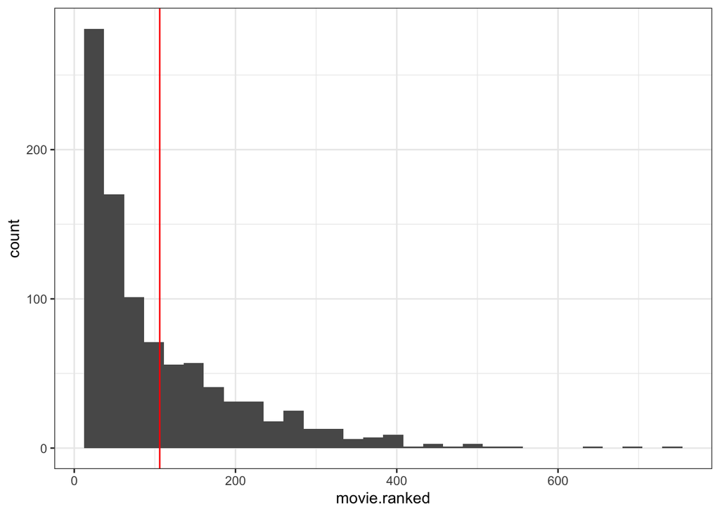

```r
movie_user %>%
  group_by(user.id) %>%
  summarise(movie.ranked = length(unique(movie.id))) %>%
  ungroup() %>%
  ggplot(.,aes(movie.ranked))+
  geom_histogram()+
  theme_bw()+
  geom_vline(xintercept = 106,color = "red")
```

#### Find the distribution of ranks

We can see that 4 is the most common rating that movie get in this dataset

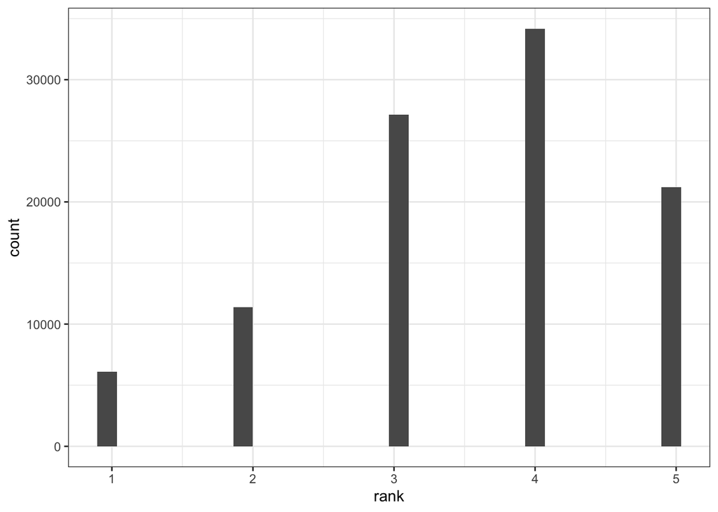

```r
movie_user %>%
  ggplot(.,aes(rank))+
  geom_histogram()+
  theme_bw()
```

#### Average movie ratings

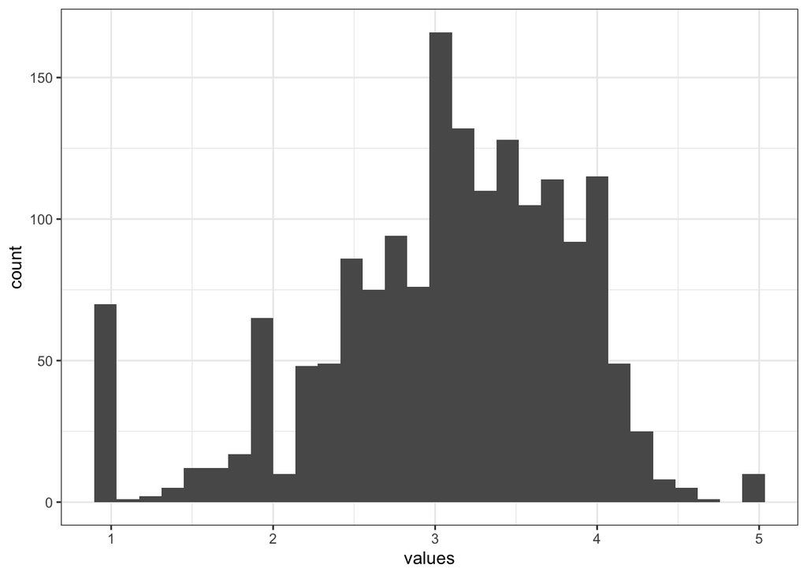

```r
movie_user %>%
  group_by(movie.id) %>%
  summarise(avg_rank = mean(rank)) %>%
  ungroup() %>%
  select(movie.id,avg_rank) %>%
  pivot_longer(cols = -movie.id,names_to = "rank_type",values_to = "values") %>%
  ggplot(.,aes(values))+
  geom_histogram()+
  theme_bw()
```

#### How many movies belong to each genera

```r
movie_data_long<- movie_data %>%
  select(1,6:length(.)) %>%
  pivot_longer(cols = -movie.id, names_to = "genera",values_to = "values") %>%
  filter(values == 1) %>%
  group_by(genera) %>%
  summarise(genera_count = sum(values)) %>%
  ungroup()
```

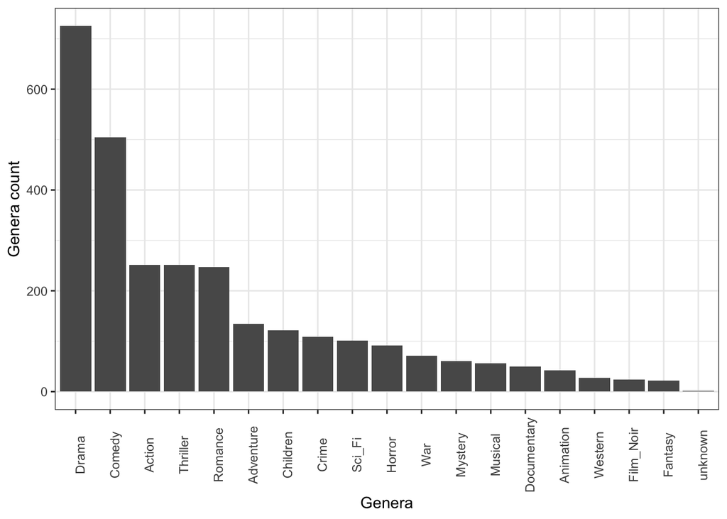

```r
movie_data_long %>%
  ggplot(.,aes(reorder(genera,-genera_count), genera_count))+
  geom_col()+
  theme_bw()+
  theme(axis.text.x = element_text(angle = 90))+
  xlab("Genera")+
  ylab("Genera count")
```

#### How many movies have one or more genera assigned to them

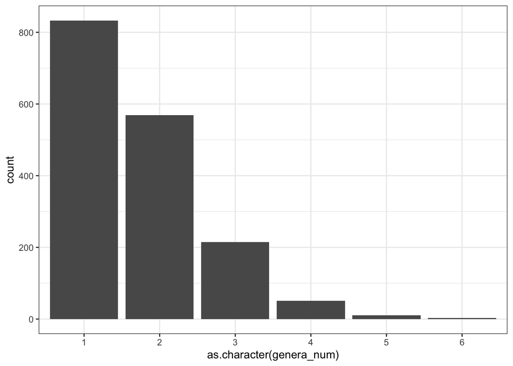

```r
movie_data %>%
  select(1,6:length(.)) %>%
  pivot_longer(cols = -movie.id, names_to = "genera",values_to = "values") %>%
  filter(values == 1) %>%
  group_by(movie.id) %>%
  summarise(genera_num = sum(values)) %>%
  ggplot(.,aes(as.character(genera_num)))+
  geom_bar()+
  theme_bw()
```

#### Average movie ratings as a function of the number of users that rated them

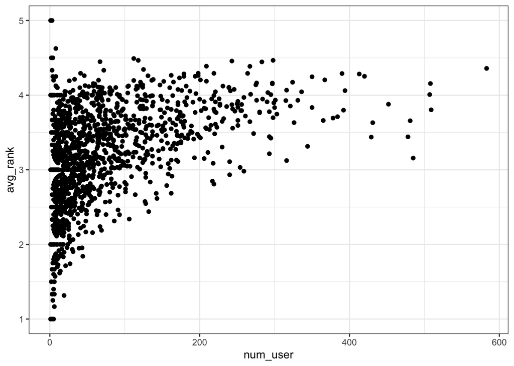

```r
movie_user %>%
  group_by(movie.id) %>%
  mutate(avg_rank = mean(rank)) %>%
  mutate(num_user = length(user.id)) %>%
  ungroup() %>%
  select(num_user,avg_rank) %>%
  distinct() %>%
  ggplot(.,aes(num_user,avg_rank))+
  geom_point()+
  theme_bw()
```

#### Average movie rating as a function of the average time passed between their release and the average rating

```r
new_movie_user<- movie_user %>%
  left_join(movie_data,by = "movie.id") %>%
  mutate(release_date = dmy(release_date)) %>%
  mutate(diff_time = as.numeric(difftime(timeUnix,release_date))) %>%
  group_by(movie.id) %>%
  mutate(min_rank_time = min(diff_time),max_rank_time = max(diff_time)) %>%
  ungroup() %>%
  select(user.id,movie.id,rank,rank_norm,diff_time,min_rank_time,max_rank_time)
```

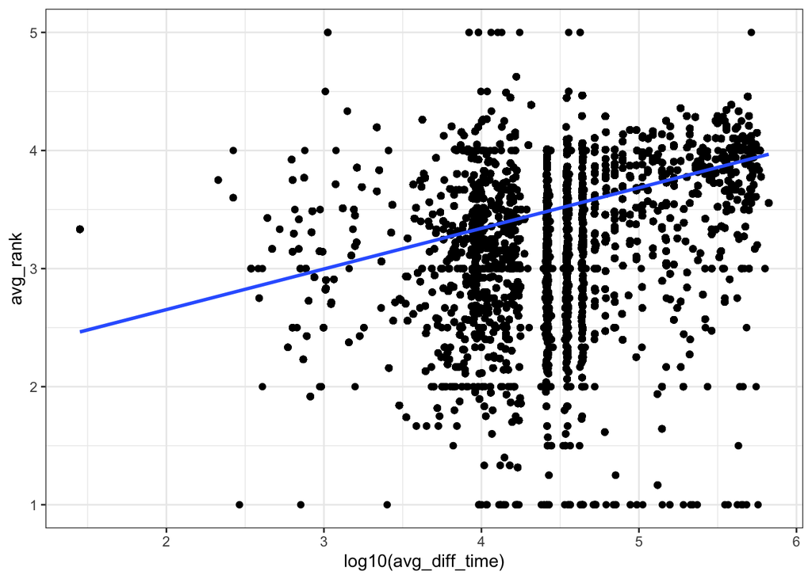

```r
new_movie_user %>%
  group_by(movie.id) %>%
  mutate(avg_rank = mean(rank),avg_diff_time = mean(diff_time,na.rm = T)) %>%
  ungroup() %>%
  ggplot(.,aes(log10(avg_diff_time),avg_rank))+
  geom_point()+
  theme_bw()+
  geom_smooth(method = "lm")
```

#### Test is this correlation is significant

```r
new_movie_user %>%
  group_by(movie.id) %>%
  mutate(avg_rank = mean(rank),avg_diff_time = mean(diff_time,na.rm = T)) %>%
  ungroup() %>%
  lm(avg_rank~log10(avg_diff_time),data = .) %>%
  summary() %>%
  broom::tidy() %>%
  knitr::kable()
```

| term | estimate | std.error | statistic | p.value |
| --- | --- | --- | --- | --- |
| (Intercept) | 1.9643410 | 0.0114903 | 170.9560 | 0 |
| log10(avg_diff_time) | 0.3440893 | 0.0025052 | 137.3484 | 0 |

#### Average rating based on genera

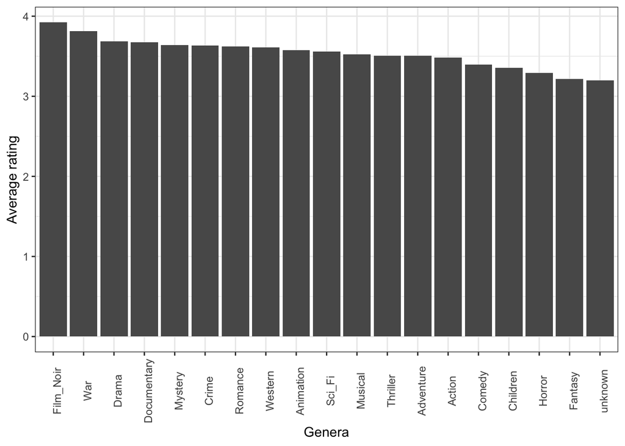

```r
movie_data %>%
  select(1,6:length(.)) %>%
  pivot_longer(cols = -movie.id, names_to = "genera",values_to = "values") %>%
  filter(values == 1) %>%
  group_by(genera) %>%
  mutate(genera_count = sum(values)) %>%
  ungroup()  %>%
  left_join(movie_user, by = "movie.id") %>%
  group_by(genera) %>%
  mutate(avg_rank = mean(rank)) %>%
  select(genera,avg_rank) %>%
  distinct() %>%
  ggplot(.,aes(reorder(genera,-avg_rank),avg_rank))+
  geom_col()+
  theme_bw()+
  theme(axis.text.x = element_text(angle = 90))+
  xlab("Genera")+
  ylab("Average rating")
```

#### Average rating as a function of how many genera there are

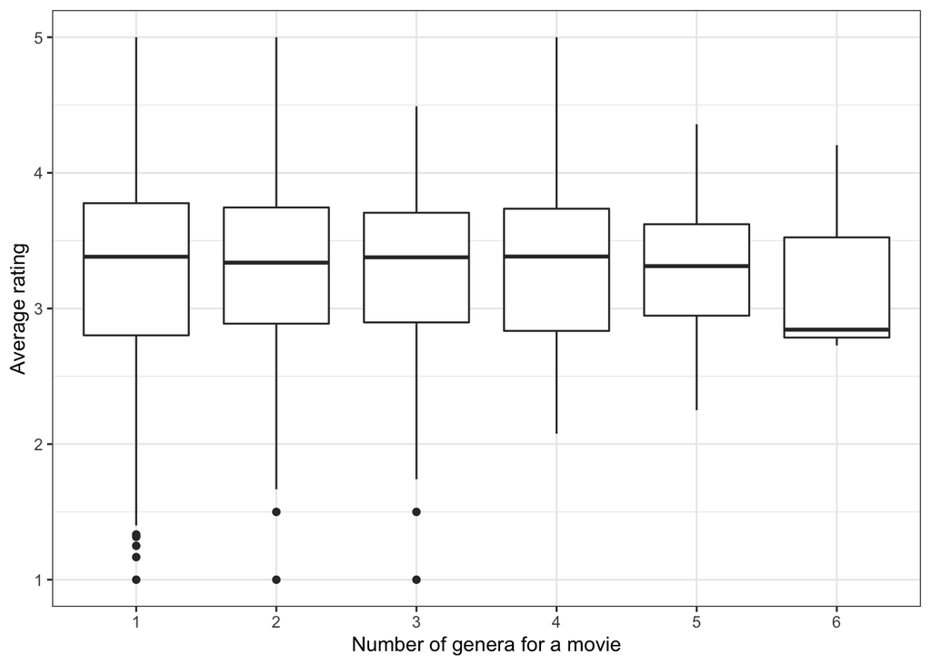

```r
movie_data %>%
  select(1,6:length(.)) %>%
  pivot_longer(cols = -movie.id, names_to = "genera",values_to = "values") %>%
  filter(values == 1) %>%
  group_by(movie.id) %>%
  mutate(genera_num = sum(values))%>%
  ungroup()  %>%
  left_join(movie_user, by = "movie.id") %>%
  group_by(movie.id) %>%
  mutate(avg_rank = mean(rank)) %>%
  ungroup() %>%
  select(genera_num,avg_rank) %>%
  distinct() %>%
  ggplot(.,aes(as.character(genera_num),avg_rank))+
  geom_boxplot()+
  theme_bw()+
  labs(x = "Number of genera for a movie", y = "Average rating")
```

# Building the recommendation system

First do some data manipulation to convert the data type into a type that works with the package `recommenderlab`. I decided to compare the models performance with using the true ranks and the binary of like-only matrix. The package does not have an option to caculate all the parameters that allow to compare the performance for the binary data so I will focus on the true ranks.

```r
movie_ranke_m<- movie_user %>%
  select(user.id,movie.id,rank) %>%
  pivot_wider(id_cols = "user.id",names_from = "movie.id",values_from = "rank",values_fill = NA) %>%
  select(-user.id) %>%
  as.matrix()
#Convert rating matrix into a recommenderlab sparse matrix
user_id<- movie_user %>%
  select(user.id,movie.id,rank) %>%
  pivot_wider(id_cols = "user.id",names_from = "movie.id",values_from = "rank",values_fill = NA) %>%
  select(user.id) %>%
  as.vector()
rownames(movie_ranke_m)<- user_id$user.id
ratingmat<- movie_ranke_m
ratingmat <- as(ratingmat, "realRatingMatrix")
```

The data has some users that invested very little in ranking the items and some items that have very little ranking. This type of data is not very informative and does not give us enough power to use for prediction.

```r
paste0("Minimum rankings a user gave: ",min(rowCounts(ratingmat)))
```

```
## [1] "Minimum rankings a user gave: 20"
```

```r
paste0("Minimum rankings an item got: ", min(colCounts(ratingmat)))
```

```
## [1] "Minimum rankings an item got: 1"
```

We can see that the a user with the minimum rankings is 20 but there is at least one item that got a rating from only one user. This is not very informative. Thus I will remove any users and items that have less than 50 ranking. This is a qualitative decision and it might be worth to play around with this number to see whether some more data can be retained by decreasing the minimum number of rankings to consider.

```r
#for true rankings
ratings_movies <- ratingmat[rowCounts(ratingmat) > 50,
                            colCounts(ratingmat) > 50]
```

After converting the data into the proper data for the package and binarizing it I will split it into train and test data. The data that comes from kaggle has a split train and test data that is a 80/20 split but as it is a random split I decided it will be easier to split the subsetted data using the functions from the `recommenderlab` package.

```r
set.seed(182)
eval_split<- evaluationScheme(ratings_movies, method="split", train=0.8,given=10, goodRating = 3)
```

```r
recc_model_popular <- Recommender(data = getData(eval_split, "train"),
                               method = "RANDOM")
```

```r
recc_predicted_popular <- predict(object = recc_model_popular,
                          newdata = getData(eval_split, "known"),type = "ratingMatrix")
recc_predicted_popular_n <- predict(object = recc_model_popular,
                          newdata = getData(eval_split, "known"))
```

```r
predict_p<- bind_rows(recc_predicted_popular_n@items)


rand_user_data_p<-predict_p[,rand_up]


rand_user_data_p<- rand_user_data_p %>%
  rename(user_49 = `49`,user_72 = `72`,user_99 = `99`)

rand_user_data_p %>%
  reshape2::melt() %>%
  mutate(value = as.character(value)) %>%
  left_join(movie_data_sub,by = c("value" = "movie.id")) %>%
  mutate(id.col = rep(1:10,3)) %>%
  pivot_wider(id_cols = "id.col",names_from = "variable",values_from = "movie_title") %>%
  select(-id.col) %>%
  knitr::kable()
```

| user_49 | user_72 | user_99 |
| --- | --- | --- |
| Forrest Gump (1994) | Tombstone (1993) | Die Hard: With a Vengeance (1995) |
| Return of the Pink Panther, The (1974) | Village of the Damned (1995) | Mission: Impossible (1996) |
| Rainmaker, The (1997) | Diabolique (1996) | Mad Love (1995) |
| Apt Pupil (1998) | Batman Returns (1992) | Fugitive, The (1993) |
| Kingpin (1996) | Twister (1996) | Forrest Gump (1994) |
| Burnt Offerings (1976) | Playing God (1997) | Outbreak (1995) |
| Anastasia (1997) | Long Kiss Goodnight, The (1996) | 187 (1997) |
| U Turn (1997) | Dirty Dancing (1987) | Big Night (1996) |
| Smoke (1995) | Unforgiven (1992) | Beavis and Butt-head Do America (1996) |
| Bronx Tale, A (1993) | Beverly Hills Ninja (1997) | Remains of the Day, The (1993) |

```r
eval_accuracy_p_u<- calcPredictionAccuracy(recc_predicted_popular, getData(eval_split, "unknown"),goodRating = 3,given=10,byUser = T)
P_RMSE<- data.frame(P_RMSE = eval_accuracy_p_u[,"RMSE"],user.id = rownames(eval_accuracy_p_u))
```

### 2. User-based recommender

This type of model utilizes the recommendations from similar users to recommend products to a user. This is a “word-to-moth” type of approach. It first finds similar users and then finds the products these users liked to recommend them to users that didn’t rate these product. This is a good method to use when you have good amount of rating data from many users. The big drawback of this method is that it is is not scaleble because you need to rerun the similarity matrix everytime you get new information.

```r
recc_model_user <- Recommender(data = getData(eval_split, "train"),
                               method = "UBCF")
```

```r
recc_predicted_user <- predict(object = recc_model_user,
                               newdata = getData(eval_split, "known"),type = "ratingMatrix")
recc_predicted_user_n <- predict(object = recc_model_user,
                               newdata = getData(eval_split, "known"))
```

```r
predict_u<- bind_rows(recc_predicted_user_n@items)


rand_user_data_u<-predict_u[,rand_up]


rand_user_data_u<- rand_user_data_u %>%
  rename(user_49 = `49`,user_72 = `72`,user_99 = `99`)

rand_user_data_u %>%
  reshape2::melt() %>%
  mutate(value = as.character(value)) %>%
  left_join(movie_data_sub,by = c("value" = "movie.id")) %>%
  mutate(id.col = rep(1:10,3)) %>%
  pivot_wider(id_cols = "id.col",names_from = "variable",values_from = "movie_title") %>%
  select(-id.col) %>%
  knitr::kable()
```

| user_49 | user_72 | user_99 |
| --- | --- | --- |
| Addams Family Values (1993) | Air Force One (1997) | Stargate (1994) |
| Mystery Science Theater 3000: The Movie (1996) | My Left Foot (1989) | Quiz Show (1994) |
| Age of Innocence, The (1993) | Beauty and the Beast (1991) | Interview with the Vampire (1994) |
| Raiders of the Lost Ark (1981) | Candidate, The (1972) | Miller’s Crossing (1990) |
| Jaws 2 (1978) | Star Trek VI: The Undiscovered Country (1991) | George of the Jungle (1997) |
| Sting, The (1973) | Jude (1996) | Flintstones, The (1994) |
| Butch Cassidy and the Sundance Kid (1969) | Quiz Show (1994) | Butch Cassidy and the Sundance Kid (1969) |
| Sling Blade (1996) | East of Eden (1955) | Incognito (1997) |
| Raging Bull (1980) | Amityville Curse, The (1990) | East of Eden (1955) |
| In & Out (1997) | Lawnmower Man, The (1992) | White Man’s Burden (1995) |

```r
eval_accuracy_UB_u<- calcPredictionAccuracy(recc_predicted_user, getData(eval_split, "unknown"),goodRating = 3,given=10,byUser = T)
UB_RMSE<- data.frame(UB_RMSE = eval_accuracy_UB_u[,"RMSE"],user.id = rownames(eval_accuracy_UB_u))
```

### 3. Item-based recommender

This is similar to the user-based approach but here assumes that users would like similar items. It first finds similar items and then recommends to the users items it didn’t rate yet. This method is again not scaleble so is only useful if you have a managble data size, which is not the case in many companies. Another drawback of this method is that it will rarely help the user to explore new products outside of the scope of their previous ranking.

```r
recc_model_item <- Recommender(data = getData(eval_split, "train"),
                                  method = "IBCF")
```

```r
recc_predicted_item <- predict(object = recc_model_item,
                                  newdata = getData(eval_split, "known"),type = "ratingMatrix")
recc_predicted_item_n <- predict(object = recc_model_item,
                                  newdata = getData(eval_split, "known"))
```

```r
predict_i<- bind_rows(recc_predicted_item_n@items)


rand_user_data_i<-predict_i[,rand_up]


rand_user_data_i<- rand_user_data_i %>%
  rename(user_49 = `49`,user_72 = `72`,user_99 = `99`)

rand_user_data_i %>%
  reshape2::melt() %>%
  mutate(value = as.character(value)) %>%
  left_join(movie_data_sub,by = c("value" = "movie.id")) %>%
  mutate(id.col = rep(1:10,3)) %>%
  pivot_wider(id_cols = "id.col",names_from = "variable",values_from = "movie_title") %>%
  select(-id.col) %>%
  knitr::kable()
```

| user_49 | user_72 | user_99 |
| --- | --- | --- |
| Ghost and the Darkness, The (1996) | Toy Story (1995) | Doom Generation, The (1995) |
| Psycho (1960) | Shanghai Triad (Yao a yao yao dao waipo qiao) (1995) | Hot Shots! Part Deux (1993) |
| Nightmare on Elm Street, A (1984) | Usual Suspects, The (1995) | Hudsucker Proxy, The (1994) |
| Clueless (1995) | Postino, Il (1994) | Sgt. Bilko (1996) |
| Full Metal Jacket (1987) | Angels and Insects (1995) | Godfather, The (1972) |
| Henry V (1989) | Birdcage, The (1996) | Henry V (1989) |
| Piano, The (1993) | Crumb (1994) | Nutty Professor, The (1996) |
| First Wives Club, The (1996) | Free Willy 2: The Adventure Home (1995) | Man Who Would Be King, The (1975) |
| Four Rooms (1995) | To Wong Foo, Thanks for Everything! Julie Newmar (1995) | Things to Do in Denver when You’re Dead (1995) |
| Babe (1995) | Exotica (1994) | Star Trek: Generations (1994) |

```r
eval_accuracy_IB_u<- calcPredictionAccuracy(recc_predicted_item, getData(eval_split, "unknown"),goodRating = 3,given=10,byUser = T)
IB_RMSE<- data.frame(IB_RMSE = eval_accuracy_IB_u[,"RMSE"],user.id = rownames(eval_accuracy_IB_u))
```

### 4. Matrix Factorization

The idea behind matrix factorization is to choose several latent factors (rule of thumb is 5 but can be more or less and can be optimized). These factors represent the relationship between the users and movies. Taking the dot product for each user and movie vectors will give us the ranking at the cell that represents that user-movie combination. We start with random number and calculate the predictions of the rating. The first predictions will be bad but we can then optimize these latent factors using gradient decent or a different optimization technique and use them to predict which other movies the user will like. We calculate the Squared Error Loss between the random prediction and the real data and use it as the loss function then we optimize it to find the lowest RSME.

```r
train_data<- getData(eval_split, "train")
train_data_long<- as(train_data,"matrix") %>%
  as.data.frame() %>%
  mutate(user.id = rownames(.)) %>%
  pivot_longer(cols = -user.id,names_to = "movie.id",values_to = "rank") %>%
  na.omit()
# now I will convert it to the recosystem data type
train_data_eco<- with(train_data_long, data_memory(user_index = user.id,
                                              item_index = movie.id,
                                              rating     = rank))

# Create the model object
r <-  recosystem::Reco()

# optimize the parameters
opts <- r$tune(train_data_eco, opts = list(dim = c(10, 20, 30),
                                       lrate = c(0.1, 0.2),
                                       costp_l2 = c(0.01, 0.1),
                                       costq_l2 = c(0.01, 0.1),
                                       nthread  = 4, niter = 10))


# Now lets add those into the model wrap in recommandlab
recc_model_MF <- Recommender(data = getData(eval_split, "train"),
                              method = "LIBMF",param = list(costp_l2 = opts$min$costp_l2,costq_l2 = opts$min$costq_l2,dim = opts$min$dim))

# now lets predict and see how it performs
recc_predicted_MF <- predict(object = recc_model_MF,
                              newdata = getData(eval_split, "known"),type = "ratingMatrix")
recc_predicted_MF_n <- predict(object = recc_model_MF,
                              newdata = getData(eval_split, "known"))
```

```r
predict_mf<- bind_rows(recc_predicted_MF_n@items)


rand_user_data_mf<-predict_mf[,rand_up]


rand_user_data_mf<- rand_user_data_mf %>%
  rename(user_49 = `49`,user_72 = `72`,user_99 = `99`)

rand_user_data_mf %>%
  reshape2::melt() %>%
  mutate(value = as.character(value)) %>%
  left_join(movie_data_sub,by = c("value" = "movie.id")) %>%
  mutate(id.col = rep(1:10,3)) %>%
  pivot_wider(id_cols = "id.col",names_from = "variable",values_from = "movie_title") %>%
  select(-id.col) %>%
  knitr::kable()
```

| user_49 | user_72 | user_99 |
| --- | --- | --- |
| East of Eden (1955) | Jean de Florette (1986) | Mirror Has Two Faces, The (1996) |
| Mystery Science Theater 3000: The Movie (1996) | Jude (1996) | Crumb (1994) |
| Jean de Florette (1986) | Ridicule (1996) | Priest (1994) |
| Dead Poets Society (1989) | Blob, The (1958) | Sound of Music, The (1965) |
| Apollo 13 (1995) | Sound of Music, The (1965) | Dead Poets Society (1989) |
| In the Name of the Father (1993) | Crumb (1994) | Jungle Book, The (1994) |
| Big Night (1996) | Dead Poets Society (1989) | North by Northwest (1959) |
| Powder (1995) | Flintstones, The (1994) | Jean de Florette (1986) |
| Crumb (1994) | Jaws 2 (1978) | My Own Private Idaho (1991) |
| Sleepless in Seattle (1993) | Time to Kill, A (1996) | Fish Called Wanda, A (1988) |

```r
eval_accuracy_MF_u<- calcPredictionAccuracy(recc_predicted_MF, getData(eval_split, "unknown"),goodRating = 3,given=10,byUser = T)
MF_RMSE<- data.frame(MF_RMSE = eval_accuracy_MF_u[,"RMSE"],user.id = rownames(eval_accuracy_MF_u))
```

Let’s summarize these parameters to see which model performed best

```r
eval_accuracy<- rbind(
  Popularity = calcPredictionAccuracy(recc_predicted_popular, getData(eval_split, "unknown"),goodRating = 3,given=10),
  User_based = calcPredictionAccuracy(recc_predicted_user, getData(eval_split, "unknown"),goodRating = 3,given=10),
  Item_based = calcPredictionAccuracy(recc_predicted_item, getData(eval_split, "unknown"),goodRating = 3,given=10),
  Matrix_factorization = calcPredictionAccuracy(recc_predicted_MF, getData(eval_split, "unknown"),goodRating = 3,given=10)
)
knitr::kable(eval_accuracy)
```

|  | RMSE | MSE | MAE |
| --- | --- | --- | --- |
| Popularity | 1.7182184 | 2.9522744 | 1.4030758 |
| User_based | 1.1381204 | 1.2953181 | 0.8915272 |
| Item_based | 1.1679601 | 1.3641309 | 0.8422459 |
| Matrix_factorization | 0.9780102 | 0.9565039 | 0.7710520 |

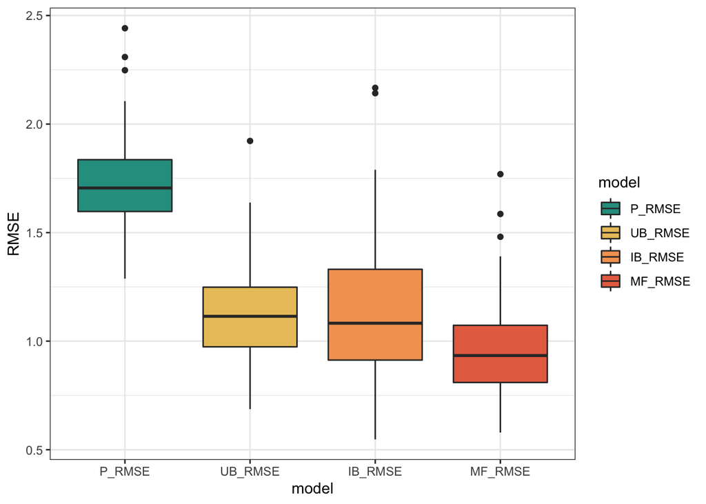

```r
all_RMSE <- data.frame(cbind(user.id = P_RMSE$user.id,
                             P_RMSE = P_RMSE$P_RMSE,
                             UB_RMSE = UB_RMSE$UB_RMSE,
                             IB_RMSE = IB_RMSE$IB_RMSE,
                             MF_RMSE = MF_RMSE$MF_RMSE))
all_RMSE %>%
  pivot_longer(cols = -user.id,names_to = "model",values_to = "RMSE") %>%
  mutate(RMSE = as.numeric(RMSE),model = factor(model, levels = c("P_RMSE","UB_RMSE","IB_RMSE","MF_RMSE"))) %>%
  ggplot(.,aes(model,RMSE,fill = model))+
  geom_boxplot()+
  theme_bw()+
  scale_fill_manual(values = c("#2a9d8f","#e9c46a","#f4a261","#e76f51"))
```

# Model Performance

We can also calculate the the error rate parameters for the true data. We want to see the lowest number. For example the Netflix recommendation system had an RMSE of 0.95 and the Netflix prize winners managed to get to RMSE of 0.85

Additional parameters that are interesting to explore:

**Recall** - How many items were recommended correctly from the total useful recommendations

**Precision - How many items were recommended correctly from the total recommended items**

**Accuracy** -How many cells were correctly predicted from the total possible recommendations (True positives + True Negatives/all data)

Recall and precision are conflicting parameters so it would be useful to find the sweet spot on where they both perform best. We can do that by calculating the F-measure which is (2/(1/Precision+1/Recall))

```r
eval_accuracy_n<- rbind(
  Popularity = calcPredictionAccuracy(recc_predicted_popular_n, getData(eval_split, "unknown"),goodRating = 3,given=10),
  User_based = calcPredictionAccuracy(recc_predicted_user_n, getData(eval_split, "unknown"),goodRating = 3,given=10),
  Item_based = calcPredictionAccuracy(recc_predicted_item_n, getData(eval_split, "unknown"),goodRating = 3,given=10),
  Matrix_factorization = calcPredictionAccuracy(recc_predicted_MF_n, getData(eval_split, "unknown"),goodRating = 3,given=10)
)
eval_accuracy_n %>%
  as.data.frame() %>%
  mutate(accuracy = (TP+TN)/(TP+TN+FP+FN)) %>%
  mutate(F_measure = (2/(1/precision+1/recall))) %>%
  mutate(model_type = rownames(.)) %>%
  select(model_type, accuracy,recall,precision,F_measure) %>%
  knitr::kable()
```

|  | model_type | accuracy | recall | precision | F_measure |
| --- | --- | --- | --- | --- | --- |
| Popularity | Popularity | 0.8253920 | 0.0143425 | 0.1433628 | 0.0260762 |
| User_based | User_based | 0.8252402 | 0.0158140 | 0.1389381 | 0.0283959 |
| Item_based | Item_based | 0.8310994 | 0.0356158 | 0.3097345 | 0.0638856 |
| Matrix_factorization | Matrix_factorization | 0.8320709 | 0.0390372 | 0.3380531 | 0.0699920 |

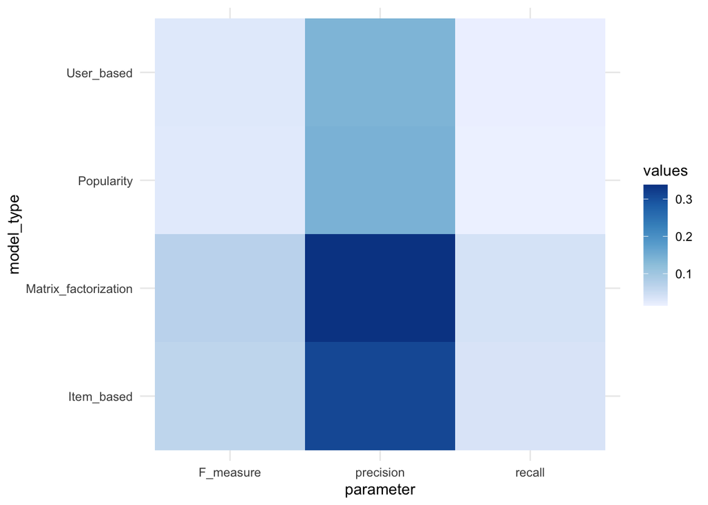

```r
eval_accuracy_n %>%
  as.data.frame() %>%
  mutate(accuracy = (TP+TN)/(TP+TN+FP+FN)) %>%
  mutate(F_measure = (2/(1/precision+1/recall))) %>%
  mutate(model_type = rownames(.)) %>%
  select(recall,precision,F_measure,model_type) %>%
  pivot_longer(cols = -model_type, names_to = "parameter",values_to = "values") %>%
  ggplot(.,aes(parameter,model_type,fill = values))+
  geom_tile()+
  scale_fill_distiller(direction = 1)+
  theme_minimal()
```

Let’s look at the distribution of these parameters by user

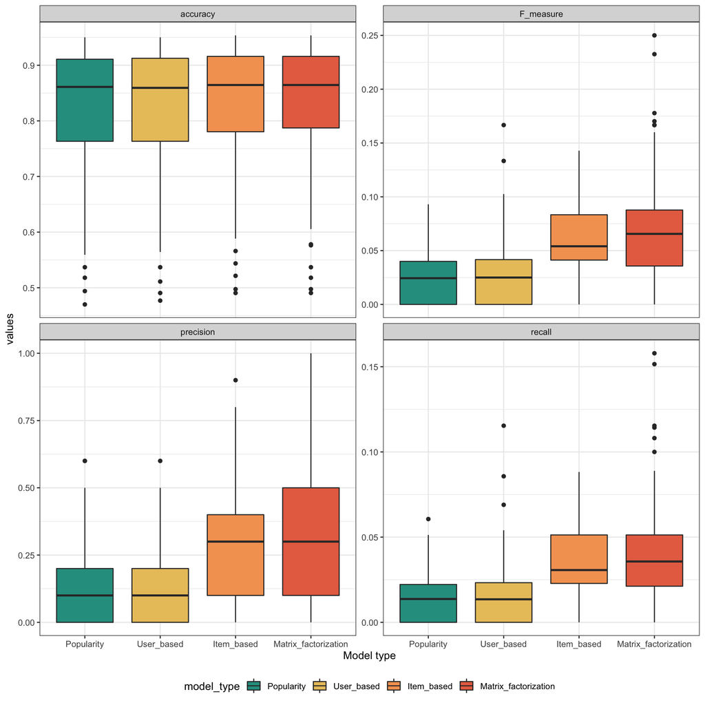

```r
Popularity_nu = as.data.frame(calcPredictionAccuracy(recc_predicted_popular_n, getData(eval_split, "unknown"),goodRating = 3,given=10,byUser = T))
Popularity_nu$model_type <- "Popularity"
User_based_nu = as.data.frame(calcPredictionAccuracy(recc_predicted_user_n, getData(eval_split, "unknown"),goodRating = 3,given=10,byUser = T))
User_based_nu$model_type<- "User_based"
Item_based_nu = as.data.frame(calcPredictionAccuracy(recc_predicted_item_n, getData(eval_split, "unknown"),goodRating = 3,given=10,byUser = T))
Item_based_nu$model_type<- "Item_based"
Matrix_factorization_nu = as.data.frame(calcPredictionAccuracy(recc_predicted_MF_n, getData(eval_split, "unknown"),goodRating = 3,given=10,byUser = T))
Matrix_factorization_nu$model_type<- "Matrix_factorization"

eval_accuracy_nu<- rbind(Popularity_nu,User_based_nu,Item_based_nu,Matrix_factorization_nu)
eval_accuracy_nu %>%
  as_tibble() %>%
  group_by(model_type) %>%
  mutate(accuracy = (TP+TN)/(TP+TN+FP+FN)) %>%
  mutate(F_measure = (2/(1/precision+1/recall))) %>%
  ungroup() %>%
  select(recall,precision,accuracy,F_measure,model_type) %>%
  pivot_longer(cols = -model_type, names_to = "parameter",values_to = "values") %>%
  mutate(model_type = factor(model_type, levels = c("Popularity","User_based","Item_based","Matrix_factorization"))) %>%
  ggplot(.,aes(model_type,values,fill = model_type))+
  geom_boxplot()+
  theme_bw()+
  scale_fill_manual(values = c("#2a9d8f","#e9c46a","#f4a261","#e76f51"))+
  facet_wrap(.~parameter,scales = "free_y")+
  theme(legend.position = "bottom")+
  xlab("Model type")
```